# Markdown

Matias

2020-12-22

## Macro 1

> Estrutura a Termo da Taxa de Juros

A curva de juros, ou *yield curve* representa o quanto as pessoas estão cobrando de juros para um determinado *devedor* a depender do tempo que ele tem para pagar. Para isso, nós vamos usar o **pacote** `GetTDData` (*Get Tesouro Direto Data*), que nos traz informações do sistema do http:://www.tesourodireto.com.br.

```r
library(GetTDData)
```

| Sigla | Título | Pré ou Pós | Índice | Cupom |
| --- | --- | --- | --- | --- |
| LTN | Letra do Tesouro Nacional | Pré | - | N |

Agora temos as informações de 23492 contratos de LTN, iniciando em 2002-03-18 até 2020-12-22. A distribuição dos contratos por ano pode ser vista no *Gráfico* abaixo:

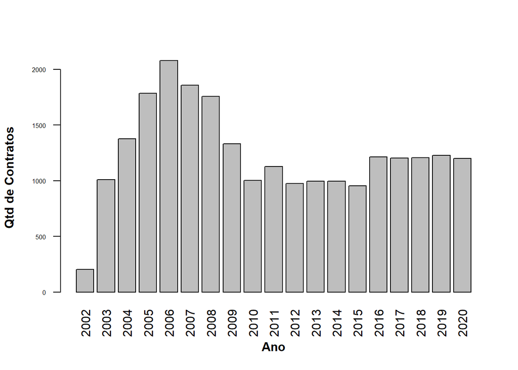

```r
anos <- c()

for(ano in unique(lubridate::year(LTN$ref.date))) {

anos <- c(anos, sum(lubridate::year(LTN$ref.date) == ano))

}

barplot(anos,
        xlab = "Ano",
        font.lab = 2,
        ylab = "Qtd de Contratos",
        names = unique(lubridate::year(LTN$ref.date)),
        las = 2,
        cex.axis = .5)
```

Vamos ver as informações dos contratos de LTN de 2020 com maior data de vencimento.

```r
knitr::kable(LTN[lubridate::year(LTN$ref.date) == 2020 &
        lubridate::year(LTN$matur.date) == max(lubridate::year(LTN$matur.date)),][1:5,],
        caption = "LTNs de 2020")
```

LTNs de 2020

|  | ref.date | yield.bid | price.bid | asset.code | matur.date |
| --- | --- | --- | --- | --- | --- |
| 11504 | 2020-02-10 | 0.0636 | 696.02 | LTN 010126 | 2026-01-01 |
| 2791 | 2020-02-11 | 0.0626 | 700.05 | LTN 010126 | 2026-01-01 |
| 3303 | 2020-02-12 | 0.0622 | 701.76 | LTN 010126 | 2026-01-01 |
| 4307 | 2020-02-13 | 0.0628 | 699.61 | LTN 010126 | 2026-01-01 |
| 5308 | 2020-02-14 | 0.0623 | 701.71 | LTN 010126 | 2026-01-01 |

A análise da queda dos juros sugerida em Pesaran, Shin, and Smith (2001).

> Opções no *chunck code*

`eval = FALSE` - Não roda o código

`include = FALSE` - Roda o código, mas não inclui no arquivo final

`echo = FALSE` - Roda o código e inclui apenas os outputs no arquivo

`message` e `warning = FALSE` - Não inclui mensagens e avisos

`results` e `fig.show = "hide"` - Não inclui resultados ou gráficos

`error = TRUE` - Knit não para ao encontar um erro

## Bibliografia

Pesaran, M, Yongcheol Shin, and Richard Smith. 2001. “Bounds Testing Approaches to the Analysis of Level Relationships.” *Journal of Applied Econometrics* 16 (3): 289–326.